# Final Project: Henry Nguyen

DACSS 601 Spring 2022

Henry Nguyen  
2022-05-14

```r
#setwd("~/Documents/R")

library(tidyverse)
library(dplyr)
library(ggplot2)
library(kableExtra)
```

# Introduction

In the United States, new infections with human immunodeficiency virus (HIV) has substantially decreased since the introduction of tolerable, highly active antiretroviral therapy. With the introduction of preexposure prophylaxis and the knowledge that someone living with HIV who has an undetectable viral load cannot transmit HIV, we have potent tools to mitigate the HIV epidemic (El-Sadr et. al., 2019). In 2019, the CDC issued a brief citing that the southern region of the United States (U.S) experiences the most significant burden of HIV, which is a shift from the dense urban cities that previously experienced the most burden(CDC, 2019). The U.S census bureau defines the southern region as Alabama, Arkansas, Delaware, District of Columbia, Florida, Georgia, Kentucky, Louisiana, Maryland, Mississippi, North Carolina, Oklahoma, South Carolina, Tennessee, Texas, Virginia, and West Virginia(U.S. Census Bureau, 2022).

As an HIV specialist in a large urban city, the burden of HIV on otherized populations is still palpable. Over the past several years, several colleagues have discussed whether or not they should go south to provide HIV primary care and whether or not it would make a difference.

The initial objective of this project was to see if there is an association between a state’s healthcare GDP and the incidence of HIV in its population. I pivoted to only look at the incidence of HIV across the U.S over time to see the trends for other regions.

# Data

### Read the dataset

I read in the data set and start tidying this data by removing rows, renaming variables, and changing variables to the appropriate form.

```r
######### CASE DATA


# Read in data set
# I skipped the first 10 rows which were notes and titles

HIV.State <- read_csv("HIV.by.State.CSV", skip = 10)

# Select rows that are relevant: Geography, Year, Cases, and Rate per 100k

HIV.State <- select(HIV.State, 2,3,5,6)

# Here I rename two columns: Geography to State, and Rate per 100k to Rate

HIV.State <- rename(HIV.State, State=2, Rate =4)

# rate is chr data, so I change it to numeric
HIV.State$Rate = as.numeric(HIV.State$Rate)


######### RATE DATA

# We have case data for 2008-2021, we only have rate data for 2008-2019. I don't have access to where they pull their state population data to calculate rate for 2020 and 2021.


# Here I create a new variable to remove 2020 and 2021 for rate data.

HIV.Rate.By.State <- filter(HIV.State, Year < 2020)

HIV.Rate.By.State <- group_by(HIV.Rate.By.State, State)

head(HIV.Rate.By.State)
```

```
# A tibble: 6 × 4
# Groups:   State [1]
   Year State   Cases  Rate
  <dbl> <chr>   <dbl> <dbl>
1  2019 Alabama   638  15.5
2  2018 Alabama   607  14.8
3  2017 Alabama   650  15.9
4  2016 Alabama   653  16
5  2015 Alabama   663  16.3
6  2014 Alabama   664  16.4
```

### Variables

The following variables are found in this table:

- **Year** : This double data which is the year of each observation.
- **State** : This is character data which is the a U.S state..
- **Cases** : This is double data which is the number of new hiv cases.
- **Rate** : This is the rate per 100,000 people.

To visualize the trends in incident data by state, I pivoted wider.

```r
##pivot wider to see year over year change for each state

HIV.State.Wide.Year <- HIV.State%>%
  select(1:3)%>%
  pivot_wider(
    names_from = Year,
    values_from = Cases
  )

## Here I use pivot wider to see year over year RATE change for each state

Rate.By.State.Wide.Year <- HIV.Rate.By.State%>%
  select(1,2,4)%>%
  pivot_wider(
    names_from = Year,
    values_from = Rate
  )
```

```r
###Table.1a

knitr::kable(HIV.State.Wide.Year,caption = "HIV Incidence by State 2008-2021" )%>%
  kable_styling("striped", full_width = F) %>%
 scroll_box(width = "1000px", height = "400px")
```

Table 1: HIV Incidence by State 2008-2021

| State | 2021 | 2020 | 2019 | 2018 | 2017 | 2016 | 2015 | 2014 | 2013 | 2012 | 2011 | 2010 | 2009 | 2008 |
| --- | --- | --- | --- | --- | --- | --- | --- | --- | --- | --- | --- | --- | --- | --- |
| Alabama | 314 | 586 | 638 | 607 | 650 | 653 | 663 | 664 | 630 | 663 | 676 | 682 | 689 | 703 |
| Alaska | 13 | 29 | 27 | 23 | 29 | 37 | 25 | 38 | 23 | 28 | 23 | 37 | 21 | 39 |
| Arizona | 505 | 668 | 761 | 753 | 727 | 714 | 689 | 742 | 685 | 620 | 564 | 615 | 641 | 681 |
| Arkansas | 264 | 244 | 287 | 278 | 287 | 315 | 271 | 311 | 262 | 247 | 237 | 230 | 279 | 234 |
| California | 2308 | 3636 | 4354 | 4715 | 4806 | 5067 | 5029 | 5113 | 4673 | 5032 | 5027 | 5270 | 5417 | 5713 |
| Colorado | 256 | 326 | 461 | 402 | 435 | 421 | 377 | 377 | 309 | 370 | 360 | 420 | 370 | 445 |
| Connecticut | 136 | 171 | 213 | 259 | 274 | 256 | 276 | 296 | 326 | 288 | 349 | 387 | 343 | 347 |
| Delaware | 55 | 95 | 93 | 91 | 126 | 111 | 104 | 115 | 110 | 137 | 114 | 124 | 149 | 153 |
| District of Columbia | 64 | 198 | 255 | 281 | 316 | 351 | 365 | 413 | 490 | 570 | 632 | 788 | 822 | 1035 |
| Florida | 3463 | 3424 | 4378 | 4530 | 4557 | 4651 | 4595 | 4483 | 4295 | 4383 | 4575 | 4639 | 5041 | 5770 |
| Georgia | 1218 | 1833 | 2439 | 2482 | 2596 | 2526 | 2627 | 2383 | 2331 | 2596 | 2628 | 2612 | 2915 | 3162 |
| Hawaii | 41 | 50 | 65 | 72 | 77 | 77 | 117 | 98 | 96 | 82 | 78 | 101 | 84 | 82 |
| Idaho | 24 | 32 | 28 | 37 | 46 | 46 | 40 | 22 | 25 | 36 | 35 | 45 | 48 | 49 |
| Illinois | 533 | 1055 | 1252 | 1374 | 1367 | 1483 | 1547 | 1536 | 1581 | 1645 | 1612 | 1650 | 1728 | 1798 |
| Indiana | 329 | 434 | 486 | 509 | 515 | 489 | 632 | 465 | 474 | 486 | 468 | 485 | 461 | 462 |
| Iowa | 81 | 100 | 100 | 116 | 125 | 132 | 124 | 94 | 119 | 117 | 113 | 114 | 124 | 95 |
| Kansas | 112 | 138 | 131 | 157 | 119 | 147 | 155 | 130 | 147 | 151 | 136 | 135 | 153 | 138 |
| Kentucky | 269 | 301 | 326 | 378 | 365 | 338 | 340 | 341 | 355 | 360 | 306 | 330 | 343 | 354 |
| Louisiana | 663 | 725 | 881 | 961 | 996 | 1108 | 1095 | 1199 | 1123 | 1018 | 1188 | 1111 | 1171 | 1063 |
| Maine | 25 | 16 | 30 | 30 | 29 | 53 | 47 | 59 | 35 | 49 | 50 | 55 | 56 | 45 |
| Maryland | 506 | 708 | 918 | 991 | 1020 | 1097 | 1168 | 1230 | 1294 | 1311 | 1412 | 1717 | 1668 | 2011 |
| Massachusetts | 157 | 431 | 535 | 649 | 608 | 640 | 598 | 648 | 671 | 706 | 674 | 702 | 683 | 742 |
| Michigan | 460 | 521 | 674 | 715 | 773 | 746 | 723 | 781 | 751 | 784 | 773 | 764 | 801 | 773 |
| Minnesota | 203 | 226 | 274 | 288 | 277 | 297 | 296 | 311 | 306 | 315 | 294 | 334 | 380 | 330 |
| Mississippi | 275 | 401 | 477 | 476 | 428 | 427 | 502 | 473 | 470 | 440 | 523 | 454 | 491 | 513 |
| Missouri | 367 | 359 | 488 | 449 | 502 | 512 | 463 | 465 | 462 | 532 | 523 | 567 | 521 | 542 |
| Montana | 9 | 15 | 25 | 23 | 32 | 20 | 19 | 14 | 22 | 20 | 21 | 20 | 31 | 22 |
| Nebraska | 62 | 73 | 81 | 79 | 88 | 75 | 78 | 87 | 80 | 81 | 78 | 116 | 108 | 96 |
| Nevada | 359 | 391 | 512 | 501 | 494 | 509 | 477 | 429 | 431 | 364 | 381 | 371 | 360 | 390 |
| New Hampshire | 22 | 29 | 31 | 38 | 32 | 39 | 25 | 41 | 36 | 48 | 40 | 50 | 38 | 43 |
| New Jersey | 601 | 763 | 1057 | 1021 | 1123 | 1188 | 1192 | 1237 | 1209 | 1277 | 1166 | 1352 | 1388 | 1429 |
| New Mexico | 93 | 123 | 156 | 135 | 141 | 146 | 137 | 135 | 140 | 115 | 137 | 148 | 160 | 152 |
| New York | 1243 | 1958 | 2330 | 2449 | 2729 | 2820 | 3051 | 3307 | 3231 | 3517 | 3773 | 3904 | 4157 | 4560 |
| North Carolina | 966 | 1077 | 1365 | 1186 | 1295 | 1388 | 1328 | 1306 | 1275 | 1228 | 1430 | 1436 | 1570 | 1695 |
| North Dakota | 15 | 36 | 40 | 36 | 38 | 46 | 20 | 20 | 19 | 9 | 13 | 14 | 13 | 12 |
| Ohio | 484 | 885 | 980 | 973 | 983 | 955 | 925 | 945 | 1037 | 1015 | 1043 | 981 | 1042 | 1054 |
| Oklahoma | 163 | 235 | 320 | 278 | 299 | 294 | 314 | 303 | 331 | 283 | 309 | 286 | 293 | 285 |
| Oregon | 130 | 181 | 199 | 230 | 203 | 228 | 223 | 238 | 229 | 270 | 239 | 238 | 248 | 286 |
| Pennsylvania | 661 | 773 | 989 | 1023 | 1100 | 1131 | 1173 | 1195 | 1286 | 1411 | 1370 | 1472 | 1645 | 1767 |
| Rhode Island | 33 | 53 | 72 | 75 | 85 | 71 | 64 | 89 | 76 | 79 | 98 | 115 | 118 | 123 |
| South Carolina | 446 | 679 | 680 | 712 | 706 | 747 | 670 | 761 | 705 | 695 | 738 | 762 | 750 | 701 |
| South Dakota | 16 | 34 | 33 | 29 | 39 | 43 | 24 | 30 | 32 | 25 | 19 | 32 | 24 | 28 |
| Tennessee | 560 | 642 | 773 | 746 | 721 | 716 | 736 | 757 | 769 | 853 | 839 | 850 | 926 | 998 |
| Texas | 2539 | 3553 | 4302 | 4422 | 4356 | 4527 | 4529 | 4419 | 4336 | 4322 | 4267 | 4445 | 4347 | 4165 |
| Utah | 85 | 129 | 135 | 121 | 113 | 139 | 123 | 113 | 109 | 120 | 107 | 83 | 122 | 131 |
| Vermont | 4 | 9 | 11 | 18 | 20 | 5 | 14 | 17 | 13 | 14 | 13 | 20 | 17 | 18 |
| Virginia | 563 | 625 | 822 | 861 | 863 | 903 | 953 | 899 | 943 | 933 | 892 | 993 | 975 | 1057 |
| Washington | 335 | 421 | 483 | 500 | 432 | 425 | 447 | 441 | 442 | 494 | 477 | 540 | 520 | 521 |
| West Virginia | 91 | 129 | 146 | 84 | 77 | 68 | 71 | 84 | 74 | 79 | 85 | 72 | 73 | 81 |
| Wisconsin | 160 | 210 | 211 | 207 | 260 | 229 | 225 | 216 | 243 | 217 | 240 | 251 | 277 | 237 |
| Wyoming | 3 | 14 | 13 | 12 | 10 | 21 | 17 | 10 | 16 | 7 | 15 | 19 | 20 | 22 |

This table helps visualization of data differently. It is still busy and hard to see trends.

### Descriptive Statistics

#### Statistics Total

```r
HIV.Statistics.Total <- HIV.State%>%
  summarise(
    "Case Mean" = mean(Cases),
    "Case Median"  = median(Cases),
    "RATE Mean" = mean(Rate, na.rm = TRUE) ,
    "RATE Median" = median(Rate, na.rm = TRUE)
    )

knitr::kable(HIV.Statistics.Total,
                  caption = "Statistics Total" )
```

Table 2: Statistics Total

| Case Mean | Case Median | RATE Mean | RATE Median |
| --- | --- | --- | --- |
| 754.1821 | 352.5 | 13.02386 | 9.6 |

#### Statistics By State

```r
HIV.Statistics.by.State <- HIV.State%>%
  group_by(State)%>%
  summarise(
    "Mean Cases by State" = mean(Cases),
    "Median Cases by State"  = median(Cases),
    "Mean Rate by State" = mean(Rate, na.rm = TRUE),
    "Median Rate by State"= median(Rate, na.rm = TRUE)
                  )

knitr::kable(HIV.Statistics.by.State,
                  caption = "Statistics by State" )%>%
  kable_styling("striped", full_width = F) %>%
 scroll_box(width = "1000px", height = "400px")
```

Table 3: Statistics by State

| State | Mean Cases by State | Median Cases by State | Mean Rate by State | Median Rate by State |
| --- | --- | --- | --- | --- |
| Alabama | 629.85714 | 658.0 | 16.408333 | 16.35 |
| Alaska | 28.00000 | 27.5 | 4.933333 | 4.60 |
| Arizona | 668.92857 | 683.0 | 12.241667 | 12.40 |
| Arkansas | 267.57143 | 267.5 | 11.016667 | 11.05 |
| California | 4725.71429 | 5028.0 | 15.841667 | 15.75 |
| Colorado | 380.64286 | 377.0 | 8.941667 | 8.80 |
| Connecticut | 280.07143 | 282.0 | 9.958333 | 9.60 |
| Delaware | 112.64286 | 112.5 | 15.325000 | 14.80 |
| District of Columbia | 470.00000 | 389.0 | 96.191667 | 79.50 |
| Florida | 4484.57143 | 4543.5 | 27.700000 | 26.50 |
| Georgia | 2453.42857 | 2561.0 | 31.608333 | 30.70 |
| Hawaii | 80.00000 | 80.0 | 7.358333 | 7.30 |
| Idaho | 36.64286 | 36.5 | 2.908333 | 2.90 |
| Illinois | 1440.07143 | 1541.5 | 14.475000 | 14.55 |
| Indiana | 478.21429 | 479.5 | 9.083333 | 8.85 |
| Iowa | 111.00000 | 115.0 | 4.450000 | 4.55 |
| Kansas | 139.21429 | 138.0 | 5.983333 | 6.05 |
| Kentucky | 336.14286 | 340.5 | 9.400000 | 9.45 |
| Louisiana | 1021.57143 | 1079.0 | 28.333333 | 28.85 |
| Maine | 41.35714 | 46.0 | 3.925000 | 4.20 |
| Maryland | 1217.92857 | 1199.0 | 26.875000 | 25.35 |
| Massachusetts | 603.14286 | 648.5 | 11.416667 | 11.45 |
| Michigan | 717.07143 | 757.5 | 9.033333 | 9.25 |
| Minnesota | 295.07143 | 296.5 | 6.858333 | 6.70 |
| Mississippi | 453.57143 | 471.5 | 19.308333 | 19.20 |
| Missouri | 482.28571 | 495.0 | 9.966667 | 9.95 |
| Montana | 20.92857 | 20.5 | 2.625000 | 2.55 |
| Nebraska | 84.42857 | 80.5 | 5.725000 | 5.25 |
| Nevada | 426.35714 | 410.0 | 18.525000 | 18.55 |
| New Hampshire | 36.57143 | 38.0 | 3.366667 | 3.40 |
| New Jersey | 1143.07143 | 1190.0 | 16.483333 | 16.15 |
| New Mexico | 137.00000 | 138.5 | 8.300000 | 8.10 |
| New York | 3073.50000 | 3141.0 | 20.100000 | 19.70 |
| North Carolina | 1324.64286 | 1317.0 | 16.766667 | 15.75 |
| North Dakota | 23.64286 | 19.5 | 3.858333 | 3.20 |
| Ohio | 950.14286 | 980.5 | 10.233333 | 10.10 |
| Oklahoma | 285.21429 | 293.5 | 9.500000 | 9.50 |
| Oregon | 224.42857 | 229.5 | 7.066667 | 7.00 |
| Pennsylvania | 1214.00000 | 1184.0 | 11.991667 | 11.40 |
| Rhode Island | 82.21429 | 77.5 | 9.825000 | 9.05 |
| South Carolina | 696.57143 | 705.5 | 17.875000 | 17.80 |
| South Dakota | 29.14286 | 29.5 | 4.291667 | 4.25 |
| Tennessee | 777.57143 | 763.0 | 14.841667 | 14.00 |
| Texas | 4180.64286 | 4341.5 | 20.350000 | 20.35 |
| Utah | 116.42857 | 120.5 | 5.200000 | 5.15 |
| Vermont | 13.78571 | 14.0 | 2.775000 | 2.85 |
| Virginia | 877.28571 | 901.0 | 13.433333 | 13.40 |
| Washington | 462.71429 | 462.0 | 8.125000 | 7.75 |
| West Virginia | 86.71429 | 80.0 | 5.308333 | 5.00 |
| Wisconsin | 227.35714 | 227.0 | 4.866667 | 4.85 |
| Wyoming | 14.21429 | 14.5 | 3.241667 | 3.25 |

#### Statistics by Year

```r
HIV.Statistics.by.Year <- HIV.State%>%
  group_by(Year)%>%
  summarise(
    "Mean Cases by Year" = mean(Cases),
    "Median Cases by Year"= median(Cases),
    "Mean Rate by Year" = mean(Rate, na.rm = TRUE),
    "Median Rate by Year" = median(Rate, na.rm = TRUE)
                  )

knitr::kable(HIV.Statistics.by.Year,
                  caption = "Statistics by Year" )%>%
  kable_styling("striped", full_width = F) %>%
 scroll_box(width = "1000px", height = "400px")
```

Table 4: Statistics by Year

| Year | Mean Cases by Year | Median Cases by Year | Mean Rate by Year | Median Rate by Year |
| --- | --- | --- | --- | --- |
| 2008 | 924.5490 | 390 | 17.17647 | 11.0 |
| 2009 | 874.9216 | 370 | 15.69804 | 10.5 |
| 2010 | 841.9216 | 387 | 14.96078 | 10.1 |
| 2011 | 807.0588 | 360 | 13.60980 | 10.0 |
| 2012 | 792.9804 | 364 | 13.03922 | 9.5 |
| 2013 | 767.1961 | 355 | 12.50196 | 9.7 |
| 2014 | 781.9608 | 377 | 12.34902 | 9.5 |
| 2015 | 778.4902 | 365 | 11.94706 | 9.5 |
| 2016 | 773.0784 | 351 | 11.92157 | 9.1 |
| 2017 | 750.7647 | 365 | 11.45882 | 9.3 |
| 2018 | 732.9804 | 378 | 10.94902 | 8.7 |
| 2019 | 712.4902 | 326 | 10.67451 | 9.0 |
| 2020 | 583.2157 | 301 | NaN | NA |
| 2021 | 436.9412 | 256 | NaN | NA |

The descriptive statistics gives us more information about the HIV epidemic in the United States. We can see that the incident cases decrease dramatically from 2008 (924) to 2021 (436). In 2008, across the states the mean is 924 and the median 390. In 2021 the mean is 436 and the median is 256. The mean rate per 100,000 people in 2008 was 17.17 and in 2019 it was 10.67. All showing a marked decrease in incident cases across the united states.

## Data Transformation

It is hard to tell a story with the tables above. The statistics start to, but one thing that would help is to see change over time which is done below by calculating the difference year over year by state. This in and of itself is helpful to start telling a story. To highlights when cases increase, I changed the font to red.

```r
##### Lag HIV CASE #####

Lag.HIV.Case <- HIV.State %>%
  group_by(State)%>%
  arrange(State,Year)%>%
  mutate(Case.Diff = Cases - lag(Cases),
         Case.Diff.Percent = ((Cases - lag(Cases))/Cases)*100,
        Increase.Case = Case.Diff > 0,
        Increase.Case.Percent = Case.Diff.Percent >0,
        )

# Lag.HIV.Case$Increase.Case = as.character(Lag.HIV.Case$Increase.Case)
# Lag.HIV.Case$Increase.Case.Percent = as.character(Lag.HIV.Case$Increase.Case.Percent)



Lag.HIV.Case.WIDE <- Lag.HIV.Case%>%
  select(1,2,5)%>%
  pivot_wider(
    names_from = Year,
    values_from = Case.Diff
  )


Table.Lag.HIV.Case.WIDE<- Lag.HIV.Case.WIDE%>%
   kbl("html",caption = "Year over Year Difference in HIV Cases by State")%>%
  kable_styling()%>%
  column_spec(3,color = if_else( Lag.HIV.Case.WIDE$`2009`>0, "red", "black", "black"))%>%
  column_spec(4,color = if_else( Lag.HIV.Case.WIDE$`2010`>0, "red", "black", "black"))%>%
  column_spec(5,color = if_else( Lag.HIV.Case.WIDE$`2011`>0, "red", "black", "black"))%>%
  column_spec(6,color = if_else( Lag.HIV.Case.WIDE$`2012`>0, "red", "black", "black"))%>%
  column_spec(7,color = if_else( Lag.HIV.Case.WIDE$`2013`>0, "red", "black", "black"))%>%
  column_spec(8,color = if_else( Lag.HIV.Case.WIDE$`2014`>0, "red", "black", "black"))%>%
  column_spec(9,color = if_else( Lag.HIV.Case.WIDE$`2015`> 0, "red", "black", "black"))%>%
  column_spec(10,color = if_else( Lag.HIV.Case.WIDE$`2016`>0, "red", "black", "black"))%>%
  column_spec(11,color = if_else( Lag.HIV.Case.WIDE$`2017`>0, "red", "black", "black"))%>%
  column_spec(12,color = if_else( Lag.HIV.Case.WIDE$`2018`>0, "red", "black", "black"))%>%
  column_spec(13,color = if_else( Lag.HIV.Case.WIDE$`2019`>0, "red", "black", "black"))%>%
  column_spec(14,color = if_else( Lag.HIV.Case.WIDE$`2020`>0, "red", "black", "black"))%>%
  column_spec(15,color = if_else( Lag.HIV.Case.WIDE$`2021`>0, "red", "black", "black"))%>%
  kable_styling("striped", full_width = F) %>%
 scroll_box(width = "1000px", height = "400px")

Table.Lag.HIV.Case.WIDE
```

Table 5: Year over Year Difference in HIV Cases by State

| State | 2008 | 2009 | 2010 | 2011 | 2012 | 2013 | 2014 | 2015 | 2016 | 2017 | 2018 | 2019 | 2020 | 2021 |
| --- | --- | --- | --- | --- | --- | --- | --- | --- | --- | --- | --- | --- | --- | --- |
| Alabama | NA | -14 | -7 | -6 | -13 | -33 | 34 | -1 | -10 | -3 | -43 | 31 | -52 | -272 |
| Alaska | NA | -18 | 16 | -14 | 5 | -5 | 15 | -13 | 12 | -8 | -6 | 4 | 2 | -16 |
| Arizona | NA | -40 | -26 | -51 | 56 | 65 | 57 | -53 | 25 | 13 | 26 | 8 | -93 | -163 |
| Arkansas | NA | 45 | -49 | 7 | 10 | 15 | 49 | -40 | 44 | -28 | -9 | 9 | -43 | 20 |
| California | NA | -296 | -147 | -243 | 5 | -359 | 440 | -84 | 38 | -261 | -91 | -361 | -718 | -1328 |
| Colorado | NA | -75 | 50 | -60 | 10 | -61 | 68 | 0 | 44 | 14 | -33 | 59 | -135 | -70 |
| Connecticut | NA | -4 | 44 | -38 | -61 | 38 | -30 | -20 | -20 | 18 | -15 | -46 | -42 | -35 |
| Delaware | NA | -4 | -25 | -10 | 23 | -27 | 5 | -11 | 7 | 15 | -35 | 2 | 2 | -40 |
| District of Columbia | NA | -213 | -34 | -156 | -62 | -80 | -77 | -48 | -14 | -35 | -35 | -26 | -57 | -134 |
| Florida | NA | -729 | -402 | -64 | -192 | -88 | 188 | 112 | 56 | -94 | -27 | -152 | -954 | 39 |
| Georgia | NA | -247 | -303 | 16 | -32 | -265 | 52 | 244 | -101 | 70 | -114 | -43 | -606 | -615 |
| Hawaii | NA | 2 | 17 | -23 | 4 | 14 | 2 | 19 | -40 | 0 | -5 | -7 | -15 | -9 |
| Idaho | NA | -1 | -3 | -10 | 1 | -11 | -3 | 18 | 6 | 0 | -9 | -9 | 4 | -8 |
| Illinois | NA | -70 | -78 | -38 | 33 | -64 | -45 | 11 | -64 | -116 | 7 | -122 | -197 | -522 |
| Indiana | NA | -1 | 24 | -17 | 18 | -12 | -9 | 167 | -143 | 26 | -6 | -23 | -52 | -105 |
| Iowa | NA | 29 | -10 | -1 | 4 | 2 | -25 | 30 | 8 | -7 | -9 | -16 | 0 | -19 |
| Kansas | NA | 15 | -18 | 1 | 15 | -4 | -17 | 25 | -8 | -28 | 38 | -26 | 7 | -26 |
| Kentucky | NA | -11 | -13 | -24 | 54 | -5 | -14 | -1 | -2 | 27 | 13 | -52 | -25 | -32 |
| Louisiana | NA | 108 | -60 | 77 | -170 | 105 | 76 | -104 | 13 | -112 | -35 | -80 | -156 | -62 |
| Maine | NA | 11 | -1 | -5 | -1 | -14 | 24 | -12 | 6 | -24 | 1 | 0 | -14 | 9 |
| Maryland | NA | -343 | 49 | -305 | -101 | -17 | -64 | -62 | -71 | -77 | -29 | -73 | -210 | -202 |
| Massachusetts | NA | -59 | 19 | -28 | 32 | -35 | -23 | -50 | 42 | -32 | 41 | -114 | -104 | -274 |
| Michigan | NA | 28 | -37 | 9 | 11 | -33 | 30 | -58 | 23 | 27 | -58 | -41 | -153 | -61 |
| Minnesota | NA | 50 | -46 | -40 | 21 | -9 | 5 | -15 | 1 | -20 | 11 | -14 | -48 | -23 |
| Mississippi | NA | -22 | -37 | 69 | -83 | 30 | 3 | 29 | -75 | 1 | 48 | 1 | -76 | -126 |
| Missouri | NA | -21 | 46 | -44 | 9 | -70 | 3 | -2 | 49 | -10 | -53 | 39 | -129 | 8 |
| Montana | NA | 9 | -11 | 1 | -1 | 2 | -8 | 5 | 1 | 12 | -9 | 2 | -10 | -6 |
| Nebraska | NA | 12 | 8 | -38 | 3 | -1 | 7 | -9 | -3 | 13 | -9 | 2 | -8 | -11 |
| Nevada | NA | -30 | 11 | 10 | -17 | 67 | -2 | 48 | 32 | -15 | 7 | 11 | -121 | -32 |
| New Hampshire | NA | -5 | 12 | -10 | 8 | -12 | 5 | -16 | 14 | -7 | 6 | -7 | -2 | -7 |
| New Jersey | NA | -41 | -36 | -186 | 111 | -68 | 28 | -45 | -4 | -65 | -102 | 36 | -294 | -162 |
| New Mexico | NA | 8 | -12 | -11 | -22 | 25 | -5 | 2 | 9 | -5 | -6 | 21 | -33 | -30 |
| New York | NA | -403 | -253 | -131 | -256 | -286 | 76 | -256 | -231 | -91 | -280 | -119 | -372 | -715 |
| North Carolina | NA | -125 | -134 | -6 | -202 | 47 | 31 | 22 | 60 | -93 | -109 | 179 | -288 | -111 |
| North Dakota | NA | 1 | 1 | -1 | -4 | 10 | 1 | 0 | 26 | -8 | -2 | 4 | -4 | -21 |
| Ohio | NA | -12 | -61 | 62 | -28 | 22 | -92 | -20 | 30 | 28 | -10 | 7 | -95 | -401 |
| Oklahoma | NA | 8 | -7 | 23 | -26 | 48 | -28 | 11 | -20 | 5 | -21 | 42 | -85 | -72 |
| Oregon | NA | -38 | -10 | 1 | 31 | -41 | 9 | -15 | 5 | -25 | 27 | -31 | -18 | -51 |
| Pennsylvania | NA | -122 | -173 | -102 | 41 | -125 | -91 | -22 | -42 | -31 | -77 | -34 | -216 | -112 |
| Rhode Island | NA | -5 | -3 | -17 | -19 | -3 | 13 | -25 | 7 | 14 | -10 | -3 | -19 | -20 |
| South Carolina | NA | 49 | 12 | -24 | -43 | 10 | 56 | -91 | 77 | -41 | 6 | -32 | -1 | -233 |
| South Dakota | NA | -4 | 8 | -13 | 6 | 7 | -2 | -6 | 19 | -4 | -10 | 4 | 1 | -18 |
| Tennessee | NA | -72 | -76 | -11 | 14 | -84 | -12 | -21 | -20 | 5 | 25 | 27 | -131 | -82 |
| Texas | NA | 182 | 98 | -178 | 55 | 14 | 83 | 110 | -2 | -171 | 66 | -120 | -749 | -1014 |
| Utah | NA | -9 | -39 | 24 | 13 | -11 | 4 | 10 | 16 | -26 | 8 | 14 | -6 | -44 |
| Vermont | NA | -1 | 3 | -7 | 1 | -1 | 4 | -3 | -9 | 15 | -2 | -7 | -2 | -5 |
| Virginia | NA | -82 | 18 | -101 | 41 | 10 | -44 | 54 | -50 | -40 | -2 | -39 | -197 | -62 |
| Washington | NA | -1 | 20 | -63 | 17 | -52 | -1 | 6 | -22 | 7 | 68 | -17 | -62 | -86 |
| West Virginia | NA | -8 | -1 | 13 | -6 | -5 | 10 | -13 | -3 | 9 | 7 | 62 | -17 | -38 |
| Wisconsin | NA | 40 | -26 | -11 | -23 | 26 | -27 | 9 | 4 | 31 | -53 | 4 | -1 | -50 |
| Wyoming | NA | -2 | -1 | -4 | -8 | 9 | -6 | 7 | 4 | -11 | 2 | 1 | 1 | -11 |

```r
# knitr::kable(Table.Lag.HIV.Case.WIDE,
#                   caption = "Table 2a: Difference in cases by Year")


Lag.HIV.Case.WIDE.Percent <- Lag.HIV.Case%>%
  select(1,2,6)%>%
  pivot_wider(
    names_from = Year,
    values_from = Case.Diff.Percent
  )

###HENRY YOU NEED TO CHANGE OUTPUT DECIMAL PLACES###

Table.Lag.HIV.Case.WIDE.Percent<- Lag.HIV.Case.WIDE.Percent%>%
   kbl("html",caption = "Year Over Year % Difference in HIV Cases by State" )%>%
  kable_styling()%>%
  column_spec(3,color = if_else( Lag.HIV.Case.WIDE$`2009`>0, "red", "black", "black"))%>%
  column_spec(4,color = if_else( Lag.HIV.Case.WIDE$`2010`>0, "red", "black", "black"))%>%
  column_spec(5,color = if_else( Lag.HIV.Case.WIDE$`2011`>0, "red", "black", "black"))%>%
  column_spec(6,color = if_else( Lag.HIV.Case.WIDE$`2012`>0, "red", "black", "black"))%>%
  column_spec(7,color = if_else( Lag.HIV.Case.WIDE$`2013`>0, "red", "black", "black"))%>%
  column_spec(8,color = if_else( Lag.HIV.Case.WIDE$`2014`>0, "red", "black", "black"))%>%
  column_spec(9,color = if_else( Lag.HIV.Case.WIDE$`2015`> 0, "red", "black", "black"))%>%
  column_spec(10,color = if_else( Lag.HIV.Case.WIDE$`2016`>0, "red", "black", "black"))%>%
  column_spec(11,color = if_else( Lag.HIV.Case.WIDE$`2017`>0, "red", "black", "black"))%>%
  column_spec(12,color = if_else( Lag.HIV.Case.WIDE$`2018`>0, "red", "black", "black"))%>%
  column_spec(13,color = if_else( Lag.HIV.Case.WIDE$`2019`>0, "red", "black", "black"))%>%
  column_spec(14,color = if_else( Lag.HIV.Case.WIDE$`2020`>0, "red", "black", "black"))%>%
  column_spec(15,color = if_else( Lag.HIV.Case.WIDE$`2021`>0, "red", "black", "black"))%>%
  kable_styling("striped", full_width = F) %>%
 scroll_box(width = "1000px", height = "400px")

Table.Lag.HIV.Case.WIDE.Percent
```

Table 5: Year Over Year % Difference in HIV Cases by State

| State | 2008 | 2009 | 2010 | 2011 | 2012 | 2013 | 2014 | 2015 | 2016 | 2017 | 2018 | 2019 | 2020 | 2021 |
| --- | --- | --- | --- | --- | --- | --- | --- | --- | --- | --- | --- | --- | --- | --- |
| Alabama | NA | -2.0319303 | -1.026393 | -0.8875740 | -1.9607843 | -5.2380952 | 5.1204819 | -0.1508296 | -1.5313936 | -0.4615385 | -7.0840198 | 4.8589342 | -8.8737201 | -86.624204 |
| Alaska | NA | -85.7142857 | 43.243243 | -60.8695652 | 17.8571429 | -21.7391304 | 39.4736842 | -52.0000000 | 32.4324324 | -27.5862069 | -26.0869565 | 14.8148148 | 6.8965517 | -123.076923 |
| Arizona | NA | -6.2402496 | -4.227642 | -9.0425532 | 9.0322581 | 9.4890511 | 7.6819407 | -7.6923077 | 3.5014006 | 1.7881706 | 3.4528552 | 1.0512484 | -13.9221557 | -32.277228 |
| Arkansas | NA | 16.1290323 | -21.304348 | 2.9535865 | 4.0485830 | 5.7251908 | 15.7556270 | -14.7601476 | 13.9682540 | -9.7560976 | -3.2374101 | 3.1358885 | -17.6229508 | 7.575758 |
| California | NA | -5.4642791 | -2.789374 | -4.8338970 | 0.0993641 | -7.6824310 | 8.6055154 | -1.6703122 | 0.7499507 | -5.4307116 | -1.9300106 | -8.2912265 | -19.7469747 | -57.538995 |
| Colorado | NA | -20.2702703 | 11.904762 | -16.6666667 | 2.7027027 | -19.7411003 | 18.0371353 | 0.0000000 | 10.4513064 | 3.2183908 | -8.2089552 | 12.7982646 | -41.4110429 | -27.343750 |
| Connecticut | NA | -1.1661808 | 11.369509 | -10.8882521 | -21.1805556 | 11.6564417 | -10.1351351 | -7.2463768 | -7.8125000 | 6.5693431 | -5.7915058 | -21.5962441 | -24.5614035 | -25.735294 |
| Delaware | NA | -2.6845638 | -20.161290 | -8.7719298 | 16.7883212 | -24.5454545 | 4.3478261 | -10.5769231 | 6.3063063 | 11.9047619 | -38.4615385 | 2.1505376 | 2.1052632 | -72.727273 |
| District of Columbia | NA | -25.9124088 | -4.314721 | -24.6835443 | -10.8771930 | -16.3265306 | -18.6440678 | -13.1506849 | -3.9886040 | -11.0759494 | -12.4555160 | -10.1960784 | -28.7878788 | -209.375000 |
| Florida | NA | -14.4614164 | -8.665661 | -1.3989071 | -4.3805613 | -2.0488941 | 4.1936203 | 2.4374320 | 1.2040421 | -2.0627606 | -0.5960265 | -3.4719050 | -27.8621495 | 1.126191 |
| Georgia | NA | -8.4734134 | -11.600306 | 0.6088280 | -1.2326656 | -11.3685114 | 2.1821234 | 9.2881614 | -3.9984165 | 2.6964561 | -4.5930701 | -1.7630176 | -33.0605565 | -50.492611 |
| Hawaii | NA | 2.3809524 | 16.831683 | -29.4871795 | 4.8780488 | 14.5833333 | 2.0408163 | 16.2393162 | -51.9480519 | 0.0000000 | -6.9444444 | -10.7692308 | -30.0000000 | -21.951220 |
| Idaho | NA | -2.0833333 | -6.666667 | -28.5714286 | 2.7777778 | -44.0000000 | -13.6363636 | 45.0000000 | 13.0434783 | 0.0000000 | -24.3243243 | -32.1428571 | 12.5000000 | -33.333333 |
| Illinois | NA | -4.0509259 | -4.727273 | -2.3573201 | 2.0060790 | -4.0480708 | -2.9296875 | 0.7110537 | -4.3155765 | -8.4857352 | 0.5094614 | -9.7444089 | -18.6729858 | -97.936210 |
| Indiana | NA | -0.2169197 | 4.948454 | -3.6324786 | 3.7037037 | -2.5316456 | -1.9354839 | 26.4240506 | -29.2433538 | 5.0485437 | -1.1787819 | -4.7325103 | -11.9815668 | -31.914894 |
| Iowa | NA | 23.3870968 | -8.771930 | -0.8849558 | 3.4188034 | 1.6806723 | -26.5957447 | 24.1935484 | 6.0606061 | -5.6000000 | -7.7586207 | -16.0000000 | 0.0000000 | -23.456790 |
| Kansas | NA | 9.8039216 | -13.333333 | 0.7352941 | 9.9337748 | -2.7210884 | -13.0769231 | 16.1290323 | -5.4421769 | -23.5294118 | 24.2038217 | -19.8473282 | 5.0724638 | -23.214286 |
| Kentucky | NA | -3.2069971 | -3.939394 | -7.8431373 | 15.0000000 | -1.4084507 | -4.1055718 | -0.2941176 | -0.5917160 | 7.3972603 | 3.4391534 | -15.9509202 | -8.3056478 | -11.895911 |
| Louisiana | NA | 9.2228864 | -5.400540 | 6.4814815 | -16.6994106 | 9.3499555 | 6.3386155 | -9.4977169 | 1.1732852 | -11.2449799 | -3.6420395 | -9.0805902 | -21.5172414 | -9.351433 |
| Maine | NA | 19.6428571 | -1.818182 | -10.0000000 | -2.0408163 | -40.0000000 | 40.6779661 | -25.5319149 | 11.3207547 | -82.7586207 | 3.3333333 | 0.0000000 | -87.5000000 | 36.000000 |
| Maryland | NA | -20.5635492 | 2.853815 | -21.6005666 | -7.7040427 | -1.3137558 | -5.2032520 | -5.3082192 | -6.4721969 | -7.5490196 | -2.9263370 | -7.9520697 | -29.6610169 | -39.920949 |
| Massachusetts | NA | -8.6383602 | 2.706553 | -4.1543027 | 4.5325779 | -5.2160954 | -3.5493827 | -8.3612040 | 6.5625000 | -5.2631579 | 6.3174114 | -21.3084112 | -24.1299304 | -174.522293 |
| Michigan | NA | 3.4956305 | -4.842932 | 1.1642950 | 1.4030612 | -4.3941411 | 3.8412292 | -8.0221300 | 3.0831099 | 3.4928849 | -8.1118881 | -6.0830861 | -29.3666027 | -13.260870 |
| Minnesota | NA | 13.1578947 | -13.772455 | -13.6054422 | 6.6666667 | -2.9411765 | 1.6077170 | -5.0675676 | 0.3367003 | -7.2202166 | 3.8194444 | -5.1094891 | -21.2389381 | -11.330049 |
| Mississippi | NA | -4.4806517 | -8.149780 | 13.1931166 | -18.8636364 | 6.3829787 | 0.6342495 | 5.7768924 | -17.5644028 | 0.2336449 | 10.0840336 | 0.2096436 | -18.9526185 | -45.818182 |
| Missouri | NA | -4.0307102 | 8.112875 | -8.4130019 | 1.6917293 | -15.1515152 | 0.6451613 | -0.4319654 | 9.5703125 | -1.9920319 | -11.8040089 | 7.9918033 | -35.9331476 | 2.179836 |
| Montana | NA | 29.0322581 | -55.000000 | 4.7619048 | -5.0000000 | 9.0909091 | -57.1428571 | 26.3157895 | 5.0000000 | 37.5000000 | -39.1304348 | 8.0000000 | -66.6666667 | -66.666667 |
| Nebraska | NA | 11.1111111 | 6.896552 | -48.7179487 | 3.7037037 | -1.2500000 | 8.0459770 | -11.5384615 | -4.0000000 | 14.7727273 | -11.3924051 | 2.4691358 | -10.9589041 | -17.741936 |
| Nevada | NA | -8.3333333 | 2.964960 | 2.6246719 | -4.6703297 | 15.5452436 | -0.4662005 | 10.0628931 | 6.2868369 | -3.0364372 | 1.3972056 | 2.1484375 | -30.9462916 | -8.913649 |
| New Hampshire | NA | -13.1578947 | 24.000000 | -25.0000000 | 16.6666667 | -33.3333333 | 12.1951220 | -64.0000000 | 35.8974359 | -21.8750000 | 15.7894737 | -22.5806452 | -6.8965517 | -31.818182 |
| New Jersey | NA | -2.9538905 | -2.662722 | -15.9519726 | 8.6922475 | -5.6244830 | 2.2635408 | -3.7751678 | -0.3367003 | -5.7880677 | -9.9902057 | 3.4058657 | -38.5321101 | -26.955075 |
| New Mexico | NA | 5.0000000 | -8.108108 | -8.0291971 | -19.1304348 | 17.8571429 | -3.7037037 | 1.4598540 | 6.1643836 | -3.5460993 | -4.4444444 | 13.4615385 | -26.8292683 | -32.258065 |
| New York | NA | -9.6944912 | -6.480533 | -3.4720382 | -7.2789309 | -8.8517487 | 2.2981554 | -8.3906916 | -8.1914894 | -3.3345548 | -11.4332381 | -5.1072961 | -18.9989785 | -57.522124 |
| North Carolina | NA | -7.9617834 | -9.331476 | -0.4195804 | -16.4495114 | 3.6862745 | 2.3736600 | 1.6566265 | 4.3227666 | -7.1814672 | -9.1905565 | 13.1135531 | -26.7409471 | -11.490683 |
| North Dakota | NA | 7.6923077 | 7.142857 | -7.6923077 | -44.4444444 | 52.6315789 | 5.0000000 | 0.0000000 | 56.5217391 | -21.0526316 | -5.5555556 | 10.0000000 | -11.1111111 | -140.000000 |
| Ohio | NA | -1.1516315 | -6.218145 | 5.9443912 | -2.7586207 | 2.1215043 | -9.7354497 | -2.1621622 | 3.1413613 | 2.8484232 | -1.0277492 | 0.7142857 | -10.7344633 | -82.851240 |
| Oklahoma | NA | 2.7303754 | -2.447552 | 7.4433657 | -9.1872792 | 14.5015106 | -9.2409241 | 3.5031847 | -6.8027211 | 1.6722408 | -7.5539568 | 13.1250000 | -36.1702128 | -44.171779 |
| Oregon | NA | -15.3225806 | -4.201681 | 0.4184100 | 11.4814815 | -17.9039301 | 3.7815126 | -6.7264574 | 2.1929825 | -12.3152709 | 11.7391304 | -15.5778894 | -9.9447514 | -39.230769 |
| Pennsylvania | NA | -7.4164134 | -11.752717 | -7.4452555 | 2.9057406 | -9.7200622 | -7.6150628 | -1.8755328 | -3.7135279 | -2.8181818 | -7.5268817 | -3.4378160 | -27.9430789 | -16.944024 |
| Rhode Island | NA | -4.2372881 | -2.608696 | -17.3469388 | -24.0506329 | -3.9473684 | 14.6067416 | -39.0625000 | 9.8591549 | 16.4705882 | -13.3333333 | -4.1666667 | -35.8490566 | -60.606061 |
| South Carolina | NA | 6.5333333 | 1.574803 | -3.2520325 | -6.1870504 | 1.4184397 | 7.3587385 | -13.5820896 | 10.3078983 | -5.8073654 | 0.8426966 | -4.7058824 | -0.1472754 | -52.242153 |
| South Dakota | NA | -16.6666667 | 25.000000 | -68.4210526 | 24.0000000 | 21.8750000 | -6.6666667 | -25.0000000 | 44.1860465 | -10.2564103 | -34.4827586 | 12.1212121 | 2.9411765 | -112.500000 |
| Tennessee | NA | -7.7753780 | -8.941176 | -1.3110846 | 1.6412661 | -10.9232770 | -1.5852048 | -2.8532609 | -2.7932961 | 0.6934813 | 3.3512064 | 3.4928849 | -20.4049844 | -14.642857 |
| Texas | NA | 4.1867955 | 2.204724 | -4.1715491 | 1.2725590 | 0.3228782 | 1.8782530 | 2.4287922 | -0.0441794 | -3.9256198 | 1.4925373 | -2.7894003 | -21.0807768 | -39.936983 |
| Utah | NA | -7.3770492 | -46.987952 | 22.4299065 | 10.8333333 | -10.0917431 | 3.5398230 | 8.1300813 | 11.5107914 | -23.0088496 | 6.6115702 | 10.3703704 | -4.6511628 | -51.764706 |
| Vermont | NA | -5.8823529 | 15.000000 | -53.8461538 | 7.1428571 | -7.6923077 | 23.5294118 | -21.4285714 | -180.0000000 | 75.0000000 | -11.1111111 | -63.6363636 | -22.2222222 | -125.000000 |
| Virginia | NA | -8.4102564 | 1.812689 | -11.3228700 | 4.3944266 | 1.0604454 | -4.8943270 | 5.6663169 | -5.5370986 | -4.6349942 | -0.2322880 | -4.7445255 | -31.5200000 | -11.012433 |
| Washington | NA | -0.1923077 | 3.703704 | -13.2075472 | 3.4412955 | -11.7647059 | -0.2267574 | 1.3422819 | -5.1764706 | 1.6203704 | 13.6000000 | -3.5196687 | -14.7268409 | -25.671642 |
| West Virginia | NA | -10.9589041 | -1.388889 | 15.2941176 | -7.5949367 | -6.7567568 | 11.9047619 | -18.3098592 | -4.4117647 | 11.6883117 | 8.3333333 | 42.4657534 | -13.1782946 | -41.758242 |
| Wisconsin | NA | 14.4404332 | -10.358566 | -4.5833333 | -10.5990783 | 10.6995885 | -12.5000000 | 4.0000000 | 1.7467249 | 11.9230769 | -25.6038647 | 1.8957346 | -0.4761905 | -31.250000 |
| Wyoming | NA | -10.0000000 | -5.263158 | -26.6666667 | -114.2857143 | 56.2500000 | -60.0000000 | 41.1764706 | 19.0476190 | -110.0000000 | 16.6666667 | 7.6923077 | 7.1428571 | -366.666667 |

```r
# knitr::kable(Table.Lag.HIV.Case.WIDE.Percent,
#                   caption = "Table 2b: Difference in Case Percentage Year Over Year by State")

###### LAG HIV RATE ######
lag.HIV.Rate <- HIV.State%>%
  group_by(State)%>%
  filter(Year < 2020)%>%
  arrange(State,Year)%>%
  mutate(Rate.Diff = Rate - lag(Rate),
         Rate.Diff.Percent =  (Rate - lag(Rate))/Rate*100,
        Increase.Rate = Rate.Diff >0,
        Increase.Rate.Percent = Rate.Diff.Percent >0)


  #kable()%>%
  #column_spec(3, color = if_else(lag.HIV.Rate$Rate.Diff<0, "black", "red"))

Lag.HIV.Rate.WIDE <- lag.HIV.Rate%>%
  select(1,2,5)%>%
  pivot_wider(
    names_from = Year,
    values_from = Rate.Diff
    )

# print(Lag.HIV.Rate.WIDE, n= 51)


# Table.Lag.HIV.Rate<- lag.HIV.Rate%>%
#   kbl()%>%
#   kable_styling()%>%
#   column_spec(3,color = spec_color(lag.HIV.Rate$Rate.Diff[1:612]))
#
Table.Lag.HIV.Rate.WIDE<- Lag.HIV.Rate.WIDE%>%
   kbl("html",caption = "Year Over Year Difference in HIV Rates by State" )%>%
  kable_styling()%>%
  column_spec(3,color = if_else( Lag.HIV.Rate.WIDE$`2009`>0, "red", "black", "black"))%>%
  column_spec(4,color = if_else( Lag.HIV.Rate.WIDE$`2010`>0, "red", "black", "black"))%>%
  column_spec(5,color = if_else( Lag.HIV.Rate.WIDE$`2011`>0, "red", "black", "black"))%>%
  column_spec(6,color = if_else( Lag.HIV.Rate.WIDE$`2012`>0, "red", "black", "black"))%>%
  column_spec(7,color = if_else( Lag.HIV.Rate.WIDE$`2013`>0, "red", "black", "black"))%>%
  column_spec(8,color = if_else( Lag.HIV.Rate.WIDE$`2014`>0, "red", "black", "black"))%>%
  column_spec(9,color = if_else( Lag.HIV.Rate.WIDE$`2015`> 0, "red", "black", "black"))%>%
  column_spec(10,color = if_else( Lag.HIV.Rate.WIDE$`2016`>0, "red", "black", "black"))%>%
  column_spec(11,color = if_else( Lag.HIV.Rate.WIDE$`2017`>0, "red", "black", "black"))%>%
  column_spec(12,color = if_else( Lag.HIV.Rate.WIDE$`2018`>0, "red", "black", "black"))%>%
  column_spec(13,color = if_else( Lag.HIV.Rate.WIDE$`2019`>0, "red", "black", "black"))%>%
  kable_styling("striped", full_width = F) %>%
 scroll_box(width = "1000px", height = "400px")

Table.Lag.HIV.Rate.WIDE
```

Table 5: Year Over Year Difference in HIV Rates by State

| State | 2008 | 2009 | 2010 | 2011 | 2012 | 2013 | 2014 | 2015 | 2016 | 2017 | 2018 | 2019 |
| --- | --- | --- | --- | --- | --- | --- | --- | --- | --- | --- | --- | --- |
| Alabama | NA | -0.5 | -0.6 | -0.2 | -0.4 | -0.9 | 0.8 | -0.1 | -0.3 | -0.1 | -1.1 | 0.7 |
| Alaska | NA | -3.3 | 2.7 | -2.5 | 0.8 | -0.9 | 2.5 | -2.1 | 1.9 | -1.3 | -1.0 | 0.7 |
| Arizona | NA | -0.9 | -0.3 | -1.2 | 0.9 | 1.0 | 0.8 | -1.1 | 0.2 | 0.0 | 0.2 | -0.1 |
| Arkansas | NA | 1.9 | -2.2 | 0.2 | 0.3 | 0.6 | 1.9 | -1.6 | 1.7 | -1.2 | -0.4 | 0.3 |
| California | NA | -1.1 | -0.9 | -0.9 | -0.2 | -1.3 | 1.3 | -0.5 | 0.0 | -0.9 | -0.3 | -1.2 |
| Colorado | NA | -2.0 | 1.1 | -1.6 | 0.1 | -1.5 | 1.4 | -0.2 | 0.8 | 0.1 | -0.8 | 1.1 |
| Connecticut | NA | -0.2 | 1.2 | -1.3 | -2.0 | 1.2 | -1.0 | -0.7 | -0.6 | 0.6 | -0.5 | -1.5 |
| Delaware | NA | -0.8 | -3.7 | -1.5 | 2.8 | -3.7 | 0.5 | -1.5 | 0.7 | 1.7 | -4.4 | 0.1 |
| District of Columbia | NA | -44.4 | -10.9 | -31.8 | -13.5 | -16.2 | -14.8 | -9.4 | -3.2 | -6.5 | -6.2 | -4.6 |
| Florida | NA | -4.9 | -3.3 | -0.8 | -1.6 | -0.9 | 0.7 | 0.2 | -0.2 | -1.0 | -0.5 | -1.2 |
| Georgia | NA | -3.7 | -3.7 | -0.2 | -0.8 | -3.5 | 0.3 | 2.5 | -1.6 | 0.4 | -1.7 | -0.8 |
| Hawaii | NA | 0.2 | 1.0 | -2.1 | 0.3 | 1.1 | 0.2 | 1.5 | -3.4 | 0.0 | -0.4 | -0.6 |
| Idaho | NA | -0.1 | -0.3 | -0.8 | 0.0 | -0.9 | -0.2 | 1.3 | 0.4 | -0.1 | -0.7 | -0.7 |
| Illinois | NA | -0.7 | -0.8 | -0.4 | 0.3 | -0.7 | -0.4 | 0.1 | -0.6 | -1.1 | 0.1 | -1.1 |
| Indiana | NA | -0.1 | 0.4 | -0.4 | 0.3 | -0.3 | -0.2 | 3.0 | -2.6 | 0.4 | -0.2 | -0.4 |
| Iowa | NA | 1.2 | -0.5 | -0.1 | 0.2 | 0.0 | -1.0 | 1.2 | 0.3 | -0.3 | -0.4 | -0.6 |
| Kansas | NA | 0.6 | -0.8 | 0.0 | 0.6 | -0.2 | -0.7 | 1.0 | -0.4 | -1.1 | 1.5 | -1.1 |
| Kentucky | NA | -0.3 | -0.5 | -0.7 | 1.5 | -0.2 | -0.4 | -0.1 | -0.1 | 0.7 | 0.3 | -1.4 |
| Louisiana | NA | 2.7 | -2.1 | 1.8 | -4.7 | 2.6 | 1.8 | -2.8 | 0.2 | -2.8 | -0.9 | -2.1 |
| Maine | NA | 1.0 | -0.2 | -0.4 | -0.1 | -1.2 | 2.0 | -1.0 | 0.5 | -2.1 | 0.1 | 0.0 |
| Maryland | NA | -7.6 | 0.3 | -6.6 | -2.3 | -0.5 | -1.5 | -1.3 | -1.5 | -1.6 | -0.7 | -1.5 |
| Massachusetts | NA | -1.2 | 0.4 | -0.6 | 0.4 | -0.7 | -0.5 | -0.9 | 0.6 | -0.6 | 0.7 | -2.0 |
| Michigan | NA | 0.3 | -0.3 | 0.0 | 0.1 | -0.4 | 0.3 | -0.7 | 0.3 | 0.3 | -0.7 | -0.5 |
| Minnesota | NA | 1.1 | -1.1 | -1.0 | 0.5 | -0.3 | 0.1 | -0.4 | 0.0 | -0.5 | 0.2 | -0.4 |
| Mississippi | NA | -1.0 | -1.8 | 2.7 | -3.4 | 1.1 | 0.1 | 1.1 | -3.0 | 0.0 | 1.9 | 0.0 |
| Missouri | NA | -0.5 | 0.9 | -0.9 | 0.1 | -1.4 | 0.0 | -0.1 | 1.0 | -0.3 | -1.1 | 0.8 |
| Montana | NA | 1.1 | -1.4 | 0.1 | -0.1 | 0.2 | -1.0 | 0.6 | 0.1 | 1.3 | -1.0 | 0.2 |
| Nebraska | NA | 0.8 | 0.4 | -2.6 | 0.1 | -0.1 | 0.5 | -0.7 | -0.2 | 0.8 | -0.6 | 0.1 |
| Nevada | NA | -1.6 | -0.1 | 0.3 | -1.0 | 2.7 | -0.4 | 1.7 | 0.9 | -1.0 | -0.1 | 0.0 |
| New Hampshire | NA | -0.4 | 1.1 | -0.9 | 0.6 | -1.0 | 0.4 | -1.4 | 1.2 | -0.7 | 0.5 | -0.6 |
| New Jersey | NA | -0.7 | -0.7 | -2.6 | 1.4 | -0.9 | 0.3 | -0.6 | -0.1 | -0.9 | -1.4 | 0.5 |
| New Mexico | NA | 0.4 | -1.0 | -0.8 | -1.3 | 1.4 | -0.3 | 0.1 | 0.5 | -0.3 | -0.4 | 1.2 |
| New York | NA | -2.6 | -1.4 | -1.0 | -1.6 | -1.8 | 0.4 | -1.6 | -1.4 | -0.5 | -1.6 | -0.7 |
| North Carolina | NA | -1.9 | -2.3 | -0.2 | -2.7 | 0.3 | 0.2 | 0.1 | 0.5 | -1.3 | -1.4 | 1.8 |
| North Dakota | NA | 0.2 | 0.1 | -0.2 | -0.8 | 1.7 | 0.1 | -0.1 | 4.2 | -1.3 | -0.3 | 0.6 |
| Ohio | NA | -0.2 | -0.6 | 0.6 | -0.3 | 0.2 | -1.0 | -0.2 | 0.3 | 0.2 | -0.1 | 0.0 |
| Oklahoma | NA | 0.2 | -0.4 | 0.7 | -1.0 | 1.5 | -1.0 | 0.3 | -0.7 | 0.1 | -0.6 | 1.2 |
| Oregon | NA | -1.3 | -0.4 | -0.1 | 0.9 | -1.3 | 0.2 | -0.5 | 0.0 | -0.8 | 0.7 | -1.0 |
| Pennsylvania | NA | -1.2 | -1.7 | -1.0 | 0.3 | -1.2 | -0.8 | -0.2 | -0.4 | -0.3 | -0.7 | -0.4 |
| Rhode Island | NA | -0.6 | -0.4 | -1.9 | -2.1 | -0.4 | 1.4 | -2.8 | 0.8 | 1.5 | -1.1 | -0.3 |
| South Carolina | NA | 1.0 | 0.0 | -0.9 | -1.3 | 0.1 | 1.1 | -2.5 | 1.6 | -1.2 | -0.1 | -1.0 |
| South Dakota | NA | -0.6 | 1.2 | -2.0 | 0.9 | 0.9 | -0.3 | -0.9 | 2.7 | -0.6 | -1.5 | 0.5 |
| Tennessee | NA | -1.6 | -1.6 | -0.4 | 0.1 | -1.6 | -0.4 | -0.5 | -0.4 | -0.1 | 0.3 | 0.3 |
| Texas | NA | 0.5 | -0.1 | -1.3 | -0.1 | -0.3 | 0.0 | 0.1 | -0.4 | -1.0 | 0.0 | -0.8 |
| Utah | NA | -0.6 | -1.8 | 1.1 | 0.5 | -0.6 | 0.1 | 0.3 | 0.6 | -1.2 | 0.2 | 0.4 |
| Vermont | NA | -0.2 | 0.5 | -1.3 | 0.2 | -0.2 | 0.7 | -0.5 | -1.7 | 2.8 | -0.4 | -1.3 |
| Virginia | NA | -1.4 | -0.1 | -1.6 | 0.4 | 0.0 | -0.7 | 0.7 | -0.8 | -0.7 | -0.1 | -0.6 |
| Washington | NA | -0.2 | 0.2 | -1.2 | 0.2 | -1.0 | -0.1 | 0.0 | -0.5 | -0.1 | 1.0 | -0.4 |
| West Virginia | NA | -0.6 | -0.1 | 0.8 | -0.4 | -0.3 | 0.6 | -0.8 | -0.2 | 0.7 | 0.4 | 4.1 |
| Wisconsin | NA | 0.9 | -0.6 | -0.3 | -0.5 | 0.6 | -0.6 | 0.1 | 0.1 | 0.6 | -1.1 | 0.1 |
| Wyoming | NA | -0.5 | -0.4 | -0.9 | -1.7 | 1.8 | -1.2 | 1.4 | 0.9 | -2.3 | 0.4 | 0.2 |

```r
# knitr::kable(Table.Lag.HIV.Rate.WIDE,
#                   caption = "Table 2c: Difference in Case Rate Year Over Year by State")

Lag.HIV.Rate.WIDE.Percent <- lag.HIV.Rate%>%
  select(1,2,6)%>%
  pivot_wider(
    names_from = Year,
    values_from = Rate.Diff.Percent
    )

#### Henry you need to change output DECIMAL PLACES

 Table.Lag.HIV.Rate.WIDE.Percent<- Lag.HIV.Rate.WIDE.Percent%>%
   kbl("html",caption = "Year Over Year % Difference in HIV Rates by State" )%>%
  kable_styling()%>%
  column_spec(3,color = if_else( Lag.HIV.Rate.WIDE$`2009`>0, "red", "black", "black"))%>%
  column_spec(4,color = if_else( Lag.HIV.Rate.WIDE$`2010`>0, "red", "black", "black"))%>%
  column_spec(5,color = if_else( Lag.HIV.Rate.WIDE$`2011`>0, "red", "black", "black"))%>%
  column_spec(6,color = if_else( Lag.HIV.Rate.WIDE$`2012`>0, "red", "black", "black"))%>%
  column_spec(7,color = if_else( Lag.HIV.Rate.WIDE$`2013`>0, "red", "black", "black"))%>%
  column_spec(8,color = if_else( Lag.HIV.Rate.WIDE$`2014`>0, "red", "black", "black"))%>%
  column_spec(9,color = if_else( Lag.HIV.Rate.WIDE$`2015`> 0, "red", "black", "black"))%>%
  column_spec(10,color = if_else( Lag.HIV.Rate.WIDE$`2016`>0, "red", "black", "black"))%>%
  column_spec(11,color = if_else( Lag.HIV.Rate.WIDE$`2017`>0, "red", "black", "black"))%>%
  column_spec(12,color = if_else( Lag.HIV.Rate.WIDE$`2018`>0, "red", "black", "black"))%>%
  column_spec(13,color = if_else( Lag.HIV.Rate.WIDE$`2019`>0, "red", "black", "black"))%>%
   kable_styling("striped", full_width = F) %>%
 scroll_box(width = "1000px", height = "400px")

Table.Lag.HIV.Rate.WIDE.Percent
```

Table 5: Year Over Year % Difference in HIV Rates by State

| State | 2008 | 2009 | 2010 | 2011 | 2012 | 2013 | 2014 | 2015 | 2016 | 2017 | 2018 | 2019 |
| --- | --- | --- | --- | --- | --- | --- | --- | --- | --- | --- | --- | --- |
| Alabama | NA | -2.824859 | -3.5087719 | -1.1834320 | -2.4242424 | -5.7692308 | 4.8780488 | -0.6134969 | -1.8750000 | -0.6289308 | -7.4324324 | 4.5161290 |
| Alaska | NA | -89.189189 | 42.1875000 | -64.1025641 | 17.0212766 | -23.6842105 | 39.6825397 | -50.0000000 | 31.1475410 | -27.0833333 | -26.3157895 | 15.5555556 |
| Arizona | NA | -7.438016 | -2.5423729 | -11.3207547 | 7.8260870 | 8.0000000 | 6.0150376 | -9.0163934 | 1.6129032 | 0.0000000 | 1.5873016 | -0.8000000 |
| Arkansas | NA | 16.101695 | -22.9166667 | 2.0408163 | 2.9702970 | 5.6074766 | 15.0793651 | -14.5454545 | 13.3858268 | -10.4347826 | -3.6036036 | 2.6315789 |
| California | NA | -6.111111 | -5.2631579 | -5.5555556 | -1.2500000 | -8.8435374 | 8.1250000 | -3.2258065 | 0.0000000 | -6.1643836 | -2.0979021 | -9.1603053 |
| Colorado | NA | -22.222222 | 10.8910891 | -18.8235294 | 1.1627907 | -21.1267606 | 16.4705882 | -2.4096386 | 8.7912088 | 1.0869565 | -9.5238095 | 11.5789474 |
| Connecticut | NA | -1.724138 | 9.3750000 | -11.3043478 | -21.0526316 | 11.2149533 | -10.3092784 | -7.7777778 | -7.1428571 | 6.6666667 | -5.8823529 | -21.4285714 |
| Delaware | NA | -3.960396 | -22.4242424 | -10.0000000 | 15.7303371 | -26.2411348 | 3.4246575 | -11.4503817 | 5.0724638 | 10.9677419 | -39.6396396 | 0.8928571 |
| District of Columbia | NA | -27.871940 | -7.3450135 | -27.2727273 | -13.0940834 | -18.6421174 | -20.5270458 | -14.9920255 | -5.3781513 | -12.2641509 | -13.2478632 | -10.9004739 |
| Florida | NA | -15.170279 | -11.3793103 | -2.8368794 | -6.0150376 | -3.5019455 | 2.6515152 | 0.7518797 | -0.7575758 | -3.9370079 | -2.0080321 | -5.0632911 |
| Georgia | NA | -10.081744 | -11.2121212 | -0.6097561 | -2.5000000 | -12.2807018 | 1.0416667 | 7.9872204 | -5.3872054 | 1.3289037 | -5.9859155 | -2.8985507 |
| Hawaii | NA | 2.564103 | 11.3636364 | -31.3432836 | 4.2857143 | 13.5802469 | 2.4096386 | 15.3061224 | -53.1250000 | 0.0000000 | -6.6666667 | -11.1111111 |
| Idaho | NA | -2.564103 | -8.3333333 | -28.5714286 | 0.0000000 | -47.3684211 | -11.7647059 | 43.3333333 | 11.7647059 | -3.0303030 | -26.9230769 | -36.8421053 |
| Illinois | NA | -4.294479 | -5.1612903 | -2.6490066 | 1.9480519 | -4.7619048 | -2.7972028 | 0.6944444 | -4.3478261 | -8.6614173 | 0.7812500 | -9.4017094 |
| Indiana | NA | -1.149425 | 4.3956044 | -4.5977011 | 3.3333333 | -3.4482759 | -2.3529412 | 26.0869565 | -29.2134831 | 4.3010753 | -2.1978022 | -4.5977011 |
| Iowa | NA | 24.000000 | -11.1111111 | -2.2727273 | 4.3478261 | 0.0000000 | -27.7777778 | 25.0000000 | 5.8823529 | -6.2500000 | -9.0909091 | -15.7894737 |
| Kansas | NA | 9.090909 | -13.7931034 | 0.0000000 | 9.3750000 | -3.2258065 | -12.7272727 | 15.3846154 | -6.5573770 | -22.0000000 | 23.0769231 | -20.3703704 |
| Kentucky | NA | -3.125000 | -5.4945055 | -8.3333333 | 15.1515152 | -2.0618557 | -4.3010753 | -1.0869565 | -1.0989011 | 7.1428571 | 2.9702970 | -16.0919540 |
| Louisiana | NA | 8.490566 | -7.0707071 | 5.7142857 | -17.5373134 | 8.8435374 | 5.7692308 | -9.8591549 | 0.6993007 | -10.8527132 | -3.6144578 | -9.2105263 |
| Maine | NA | 20.000000 | -4.1666667 | -9.0909091 | -2.3255814 | -38.7096774 | 39.2156863 | -24.3902439 | 10.8695652 | -84.0000000 | 3.8461538 | 0.0000000 |
| Maryland | NA | -21.590909 | 0.8450704 | -22.8373702 | -8.6466165 | -1.9157088 | -6.0975610 | -5.5793991 | -6.8807339 | -7.9207921 | -3.5897436 | -8.3333333 |
| Massachusetts | NA | -9.836066 | 3.1746032 | -5.0000000 | 3.2258065 | -5.9829060 | -4.4642857 | -8.7378641 | 5.5045872 | -5.8252427 | 6.3636364 | -22.2222222 |
| Michigan | NA | 3.125000 | -3.2258065 | 0.0000000 | 1.0638298 | -4.4444444 | 3.2258065 | -8.1395349 | 3.3707865 | 3.2608696 | -8.2352941 | -6.2500000 |
| Minnesota | NA | 12.643678 | -14.4736842 | -15.1515152 | 7.0422535 | -4.4117647 | 1.4492754 | -6.1538462 | 0.0000000 | -8.3333333 | 3.2258065 | -6.8965517 |
| Mississippi | NA | -4.878049 | -9.6256684 | 12.6168224 | -18.8888889 | 5.7591623 | 0.5208333 | 5.4187192 | -17.3410405 | 0.0000000 | 9.8958333 | 0.0000000 |
| Missouri | NA | -4.761905 | 7.8947368 | -8.5714286 | 0.9433962 | -15.2173913 | 0.0000000 | -1.0989011 | 9.9009901 | -3.0612245 | -12.6436782 | 8.4210526 |
| Montana | NA | 28.947368 | -58.3333333 | 4.0000000 | -4.1666667 | 7.6923077 | -62.5000000 | 27.2727273 | 4.3478261 | 36.1111111 | -38.4615385 | 7.1428571 |
| Nebraska | NA | 10.810811 | 5.1282051 | -50.0000000 | 1.8867925 | -1.9230769 | 8.7719298 | -14.0000000 | -4.1666667 | 14.2857143 | -12.0000000 | 1.9607843 |
| Nevada | NA | -9.523810 | -0.5988024 | 1.7647059 | -6.2500000 | 14.4385027 | -2.1857923 | 8.5000000 | 4.3062201 | -5.0251256 | -0.5050505 | 0.0000000 |
| New Hampshire | NA | -11.764706 | 24.4444444 | -25.0000000 | 14.2857143 | -31.2500000 | 11.1111111 | -63.6363636 | 35.2941176 | -25.9259259 | 15.6250000 | -23.0769231 |
| New Jersey | NA | -3.664922 | -3.8043478 | -16.4556962 | 8.1395349 | -5.5214724 | 1.8072289 | -3.7500000 | -0.6289308 | -6.0000000 | -10.2941176 | 3.5460993 |
| New Mexico | NA | 4.081633 | -11.3636364 | -10.0000000 | -19.4029851 | 17.2839506 | -3.8461538 | 1.2658228 | 5.9523810 | -3.7037037 | -5.1948052 | 13.4831461 |
| New York | NA | -10.276680 | -5.8577406 | -4.3668122 | -7.5117371 | -9.2307692 | 2.0100503 | -8.7431694 | -8.2840237 | -3.0487805 | -10.8108108 | -4.9645390 |
| North Carolina | NA | -9.313726 | -12.7071823 | -1.1173184 | -17.7631579 | 1.9354839 | 1.2738854 | 0.6329114 | 3.0674847 | -8.6666667 | -10.2941176 | 11.6883117 |
| North Dakota | NA | 8.333333 | 4.0000000 | -8.6956522 | -53.3333333 | 53.1250000 | 3.0303030 | -3.1250000 | 56.7567568 | -21.3114754 | -5.1724138 | 9.3750000 |
| Ohio | NA | -1.851852 | -5.8823529 | 5.5555556 | -2.8571429 | 1.8691589 | -10.3092784 | -2.1052632 | 3.0612245 | 2.0000000 | -1.0101010 | 0.0000000 |
| Oklahoma | NA | 2.061856 | -4.3010753 | 7.0000000 | -11.1111111 | 14.2857143 | -10.5263158 | 3.0612245 | -7.6923077 | 1.0869565 | -6.9767442 | 12.2448980 |
| Oregon | NA | -16.666667 | -5.4054054 | -1.3698630 | 10.9756098 | -18.8405797 | 2.8169014 | -7.5757576 | 0.0000000 | -13.7931034 | 10.7692308 | -18.1818182 |
| Pennsylvania | NA | -7.792208 | -12.4087591 | -7.8740157 | 2.3076923 | -10.1694915 | -7.2727273 | -1.8518519 | -3.8461538 | -2.9702970 | -7.4468085 | -4.4444444 |
| Rhode Island | NA | -4.545454 | -3.1250000 | -17.4311927 | -23.8636364 | -4.7619048 | 14.2857143 | -40.0000000 | 10.2564103 | 16.1290323 | -13.4146341 | -3.7974684 |
| South Carolina | NA | 5.050505 | 0.0000000 | -4.7619048 | -7.3863636 | 0.5649718 | 5.8510638 | -15.3374233 | 8.9385475 | -7.1856287 | -0.6024096 | -6.4102564 |
| South Dakota | NA | -16.666667 | 25.0000000 | -71.4285714 | 24.3243243 | 19.5652174 | -6.9767442 | -26.4705882 | 44.2622951 | -10.9090909 | -37.5000000 | 11.1111111 |
| Tennessee | NA | -9.039548 | -9.9378882 | -2.5477707 | 0.6329114 | -11.2676056 | -2.8985507 | -3.7593985 | -3.1007752 | -0.7812500 | 2.2900763 | 2.2388060 |
| Texas | NA | 2.262443 | -0.4545455 | -6.2801932 | -0.4854369 | -1.4778325 | 0.0000000 | 0.4901961 | -2.0000000 | -5.2631579 | 0.0000000 | -4.3956044 |
| Utah | NA | -10.526316 | -46.1538462 | 22.0000000 | 9.0909091 | -12.2448980 | 2.0000000 | 5.6603774 | 10.1694915 | -25.5319149 | 4.0816327 | 7.5471698 |
| Vermont | NA | -6.250000 | 13.5135135 | -54.1666667 | 7.6923077 | -8.3333333 | 22.5806452 | -19.2307692 | -188.8888889 | 75.6756757 | -12.1212121 | -65.0000000 |
| Virginia | NA | -9.395973 | -0.6756757 | -12.1212121 | 2.9411765 | 0.0000000 | -5.4263566 | 5.1470588 | -6.2500000 | -5.7851240 | -0.8333333 | -5.2631579 |
| Washington | NA | -2.127660 | 2.0833333 | -14.2857143 | 2.3255814 | -13.1578947 | -1.3333333 | 0.0000000 | -7.1428571 | -1.4492754 | 12.6582278 | -5.3333333 |
| West Virginia | NA | -12.765957 | -2.1739130 | 14.8148148 | -8.0000000 | -6.3829787 | 11.3207547 | -17.7777778 | -4.6511628 | 14.0000000 | 7.4074074 | 43.1578947 |
| Wisconsin | NA | 15.254237 | -11.3207547 | -6.0000000 | -11.1111111 | 11.7647059 | -13.3333333 | 2.1739130 | 2.1276596 | 11.3207547 | -26.1904762 | 2.3255814 |
| Wyoming | NA | -11.111111 | -9.7560976 | -28.1250000 | -113.3333333 | 54.5454545 | -57.1428571 | 40.0000000 | 20.4545455 | -109.5238095 | 16.0000000 | 7.4074074 |

## Visualize Data

Visualizing these data on graphs could help in seeing the epidemic evolve over time. To see the overall trend we see the graphs of the cases and rates by state and year. These are busy graphs.

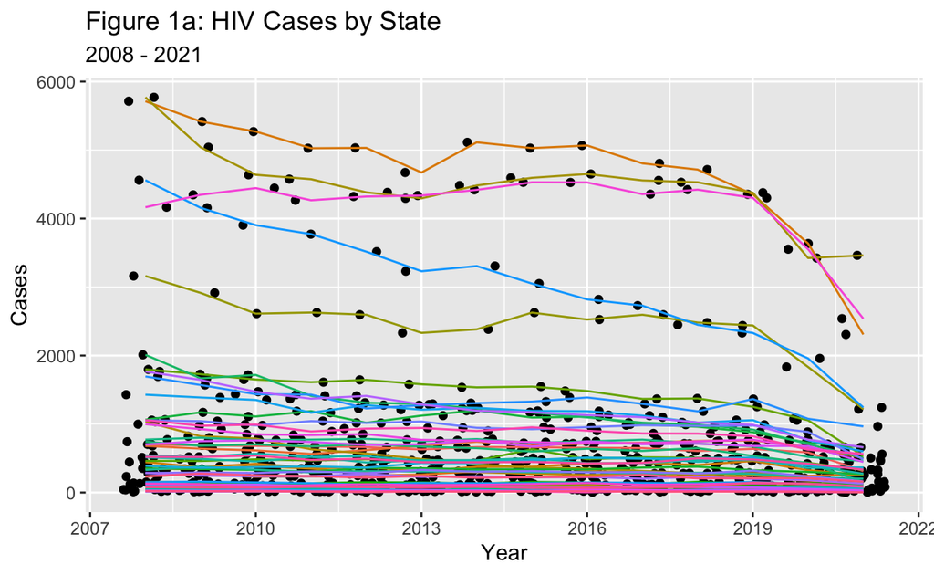

```r
# visualization of trend in cases by state from 2008-2021
Figure.1a<- HIV.State%>%
  ggplot(mapping=aes(Year,Cases))+
  geom_point(position = "jitter")+
  geom_line(mapping = aes(color= State))+
  theme(legend.position = "none")+
  labs(y = "Cases",
       title = "Figure 1a: HIV Cases by State",
       subtitle = "2008 - 2021"
  )

Figure.1a
```

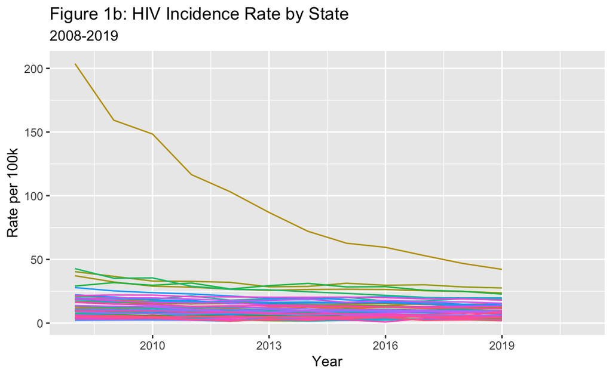

```r
# visualization of trend in rate by state from 2008-2021
Figure.1b<- HIV.State%>%
  ggplot(mapping = aes(Year,Rate))+
  geom_line(mapping = aes(Year,Rate,color = State))+
  theme(legend.position = "none")+
  labs(y = "Rate per 100k",
       title = "Figure 1b: HIV Incidence Rate by State",
       subtitle = "2008-2019")

Figure.1b
```

To see state specific trend the following figures used facet wrapping and applied logical parameters to the graph. Now we see years in which cases/rates increased or decreased by state.

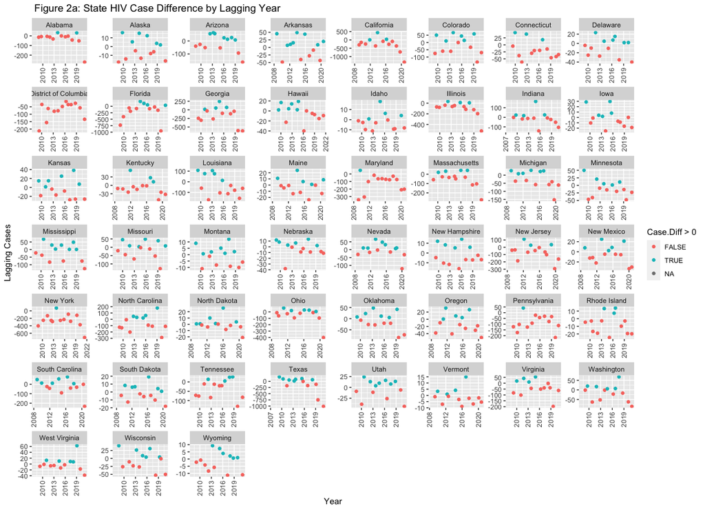

Figure 2a

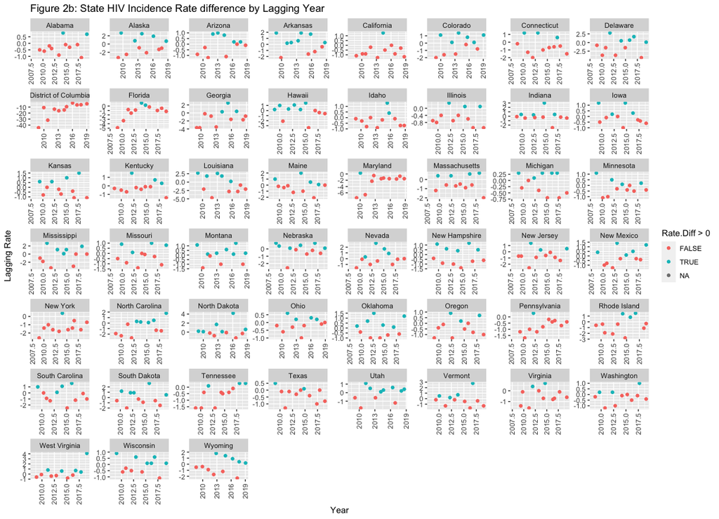

Figure 2b

```r
Figure.2a<- Lag.HIV.Case%>%
  group_by(Year)%>%
  ggplot(mapping = aes(Year,Case.Diff))+
  geom_point(aes(color = Case.Diff>0), position = "jitter")+
  facet_wrap(~State, scales = "free")+
  labs(y= " Lagging Cases",
       title = " Figure 2a: State HIV Case Difference by Lagging Year")+
  guides(x = guide_axis(angle = 90))

Figure.2b <- lag.HIV.Rate%>%
  group_by(Year)%>%
  ggplot(mapping = aes(Year,Rate.Diff))+
  geom_point(aes(color = Rate.Diff>0), position = "jitter")+
  facet_wrap(~State,scales = "free")+
  labs(y= "Lagging Rate",
       title = "Figure 2b: State HIV Incidence Rate difference by Lagging Year")+
  guides(x = guide_axis(angle = 90))
```

Graphs 2a and 2b allows us to understand the epidemic over the years by state. To visualize change year over year by state, we look at the proportion of states with positive or negative year over year change with the following bar graphs.

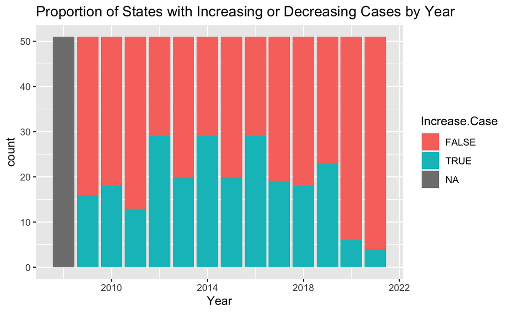

```r
Figure.3a <- Lag.HIV.Case%>%
  select(Year,State,Increase.Case)%>%
  group_by(Year,State)%>%
  arrange(Year)%>%
  ggplot()+
  geom_bar(mapping = aes(x=Year, fill = Increase.Case)
  )+
  labs(title = "Proportion of States with Increasing or Decreasing Cases by Year")

Figure.3a
```

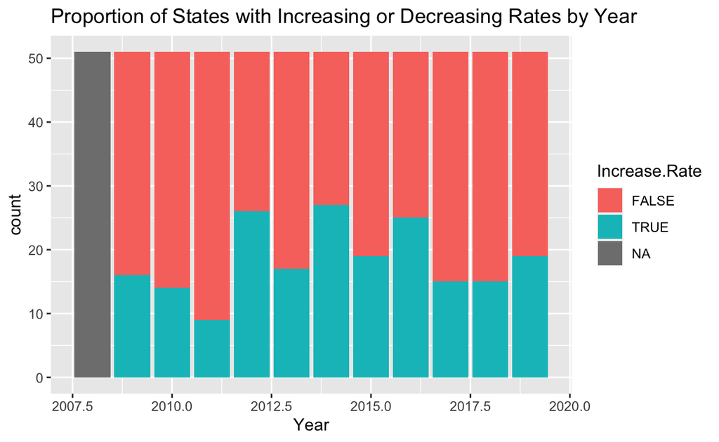

```r
Figure.3b <- lag.HIV.Rate%>%
  select(Year,State,Increase.Rate)%>%
  group_by(Year,State)%>%
  arrange(Year)%>%
  ggplot()+
  geom_bar(mapping = aes(x=Year, fill=Increase.Rate))+
  labs(title = "Proportion of States with Increasing or Decreasing Rates by Year")

Figure.3b
```

# Reflection

I took this class because, at the time, there was limited exposure to R offered in the Master in Public Health Program. As a data-driven nurse practitioner who worked in community medicine and has since moved over to work on the science side of the pharmaceutical industry. I wanted to learn R. In medicine, there is a significant push for real-world data, which more often than not are data obtained from large data repositories, analyzed, then published.

The process for this project started very slowly. I looked at several data sets, including the data sets provided by the class, but I could not settle on a data set or a combination of data sets. As I progressed through the tutorials, I felt I understood the concepts I learned from them. When I started to dive into different data sets, I found how challenging wrangling and tidying data could be. After discussing with some of my colleagues who are also HIV specialists, I settled on looking at HIV incidence data. We talked about the “epidemic of the south” and how we could help. Is it possible for us to go south and provide quality HIV and primary care, and would it even matter? I looked at this data set, hoping to identify whether HIV is genuinely just an epidemic in the southern states or do we also see concerning rates in other states. I also pulled health care GDP data, as I was curious whether there is an inverse relationship between a state’s health care GDP and its HIV rates.

# Conclusion

These data confirm that there has been a substantial decrease in incident HIV infections since 2008. It affirms that the disease burden is due to large numbers of incident cases in the southern states. We also see there are states in other regions that have increased HIV cases/rates over the past few years, although at a much lower level. HIV in these states is likely different than in the U.S south. As opposed to the socioeconomic factors and health care access issues affecting HIV treatment and prevention in the U.S South (CDC, 2019), the few infections seen in non-southern states may be related to an HIV cluster; for example, the HIV cluster in Indiana seen in 2015 (Goodnough, 2015).

I am still curious to see if there is a more inverse relationship or any relationship between health care GDP and the incidence of HIV by state. The next step I would take is to work with the healthcare GDP data and see if there is an association with incident HIV infection by state.

# Referencees

Centers for Disease Control and Prevention. NCHHSTP AtlasPlus. Updated 2017. https://www.cdc.gov/nchhstp/atlas/index.htm. Accessed on [February 2022]

Centers for Disease Control and Prevention. HIV in the southern United States: CDC Issue Brief. 2016; https://www.cdc.gov/hiv/pdf/policies/cdc-hiv-in-the-south-issue-brief.pdf. Accessed 10 Aug 2019.

El-Sadr, W. M., Mayer, K. H., Rabkin, M., & Hodder, S. L. (2019). AIDS in America—back in the headlines at long last. New England Journal of Medicine, 380(21), 1985-1987.

Goodnough, A. (2015). Rural indiana struggles to contend with HIV outbreak. New York Times, 5.

R Core Team (2022). R: A language and environment for statistical computing. R Foundation for Statistical Computing, Vienna, Austria. URL https://www.R-project.org/

U.S. Census Bureau. Census Regions and Divisions of the United States. Available at: https://www2.census.gov/geo/pdfs/maps-data/maps/reference/us_regdiv.pdf. Accessed May 2022.

Wickham, H., ggplot2: Elegant Graphics for Data Analysis. Springer-Verlag New York, 2016.

Wickham, H. et al., (2019). Welcome to the tidyverse. Journal of Open Source Software, 4(43), 1686,https://doi.org/10.21105/joss.01686

Wickham, H., François, R.,Henry,L., and Müller, K., (2021). dplyr: A Grammar of Data Manipulation. R package version 1.0.7. https://CRAN.R-project.org/package=dplyr

Wickham, H., & Grolemund, G. (2016). R for data science: Visualize, model, transform, tidy, and import data. OReilly Media.

Zhu, H (2021). kableExtra: Construct Complex Table with ‘kable’ and Pipe Syntax. R package version 1.3.4. https://CRAN.R-project.org/package=kableExtra